# Multiple Comparisons Analysis of the Memory Words Task (MSC)

John Koo

For this analysis, we will focus on session 1 for subject 1. We will look at the T1-weighted scans. This particular session consisted of 121 scans of $38 \times 49 \times 38$ voxels. Each voxel is $4 \times 4 \times 4$ mm. The scans were taken at $2.2$ second intervals.

As before, we use the model:

$$Y = X \beta + E$$

… where $Y, E \in \mathbb{R}^{T \times V}$, $X \in \mathbb{R}^{T \times p}$, and $\beta \in \mathbb{R}^{T \times V}$, $T$ is the number of scans for the session, and $V$ is the number of voxels of interest. For this session, $V = 27040$. $\beta$ is further separated into parameters of interest and nuisiance parameters. In this case, we have one parameter of interest, related to the pooled task (previous data analysis suggests that both tasks have similar activation patterns).

In OLS regression, we assume that $\epsilon_j \sim \mathcal{N}(0, \sigma_j^2 I)$ ($j$ is the column index of $E$). However, since we have timeseries data, it makes more sense to say $\epsilon_j \sim \mathcal{N}(0, \sigma_j^2 V)$ where $V \in \mathbb{R}^{T \times T}$ takes on an autocorrelated structure. But if we multiply everything by $W$ where $W^\top W = V^{-1}$, we get $W \epsilon_j \sim \mathcal{N}(0, \sigma^2_j I)$. The model then becomes $W Y = W X \beta + W E$ where $W \epsilon_j$ is multivariate normal with diagonal constant variance (note that while we use the same $W$ across all $V$ voxels, we allow $\sigma_j^2$ to vary from voxel to voxel). For this analysis, we will model the timeseries using an AR(4) process.

Using $\alpha = 0.05$, we can individually classify the voxels as activated ($T > t_{\alpha}$):

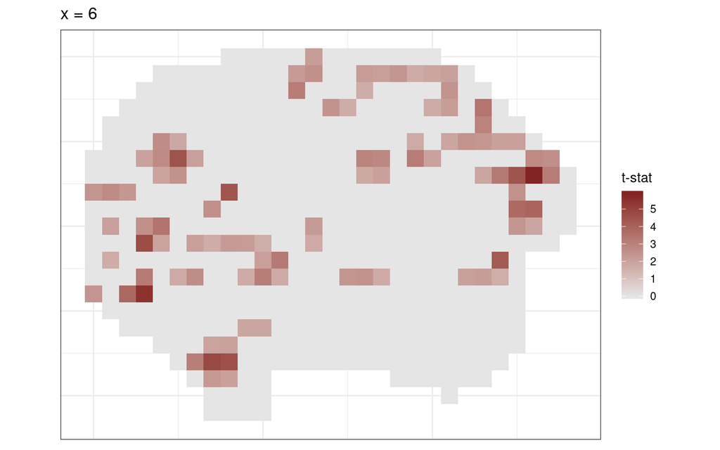

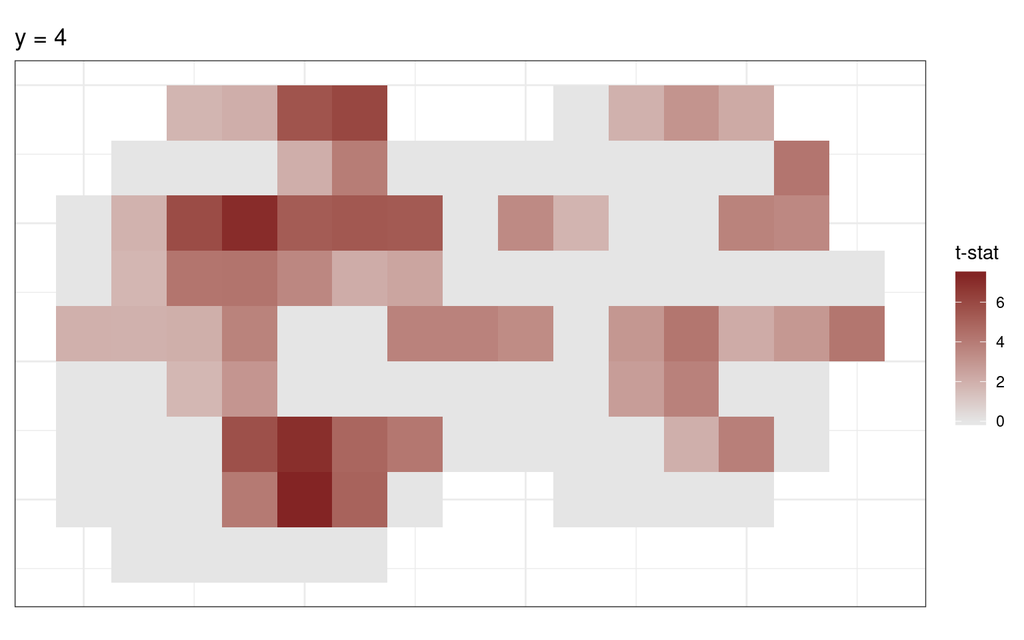

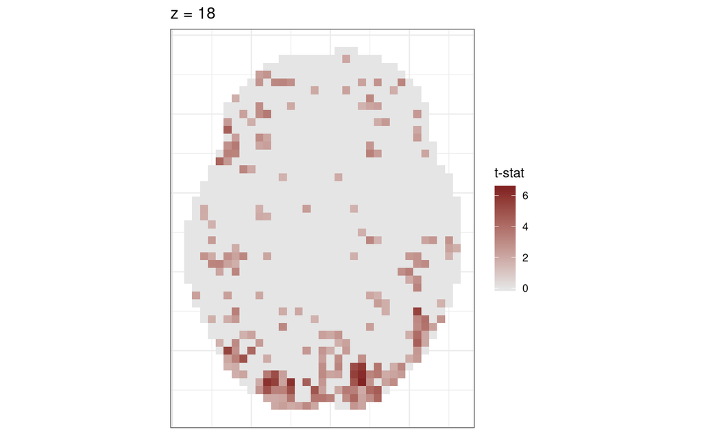

However, we have 27040 voxels, so if there were no activation, we would expect on average 1352 false positives. The number of activations we get from a naive voxel-level analysis is 3223. This means that in our analysis, we expect 42% of our “active” voxels to be false positives.

Performing the same analysis with the Bonferroni correction:

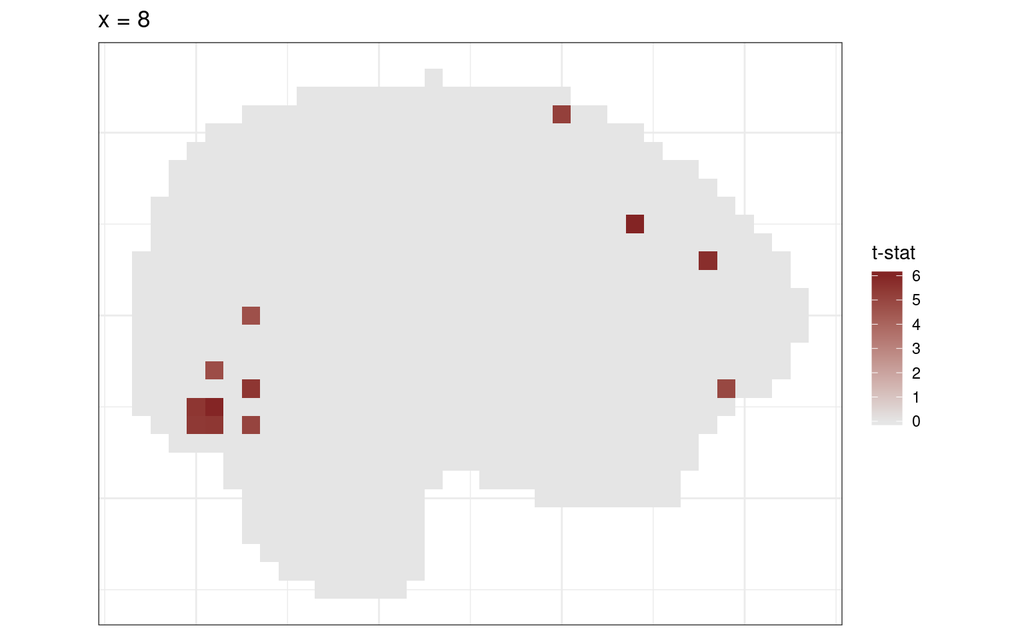

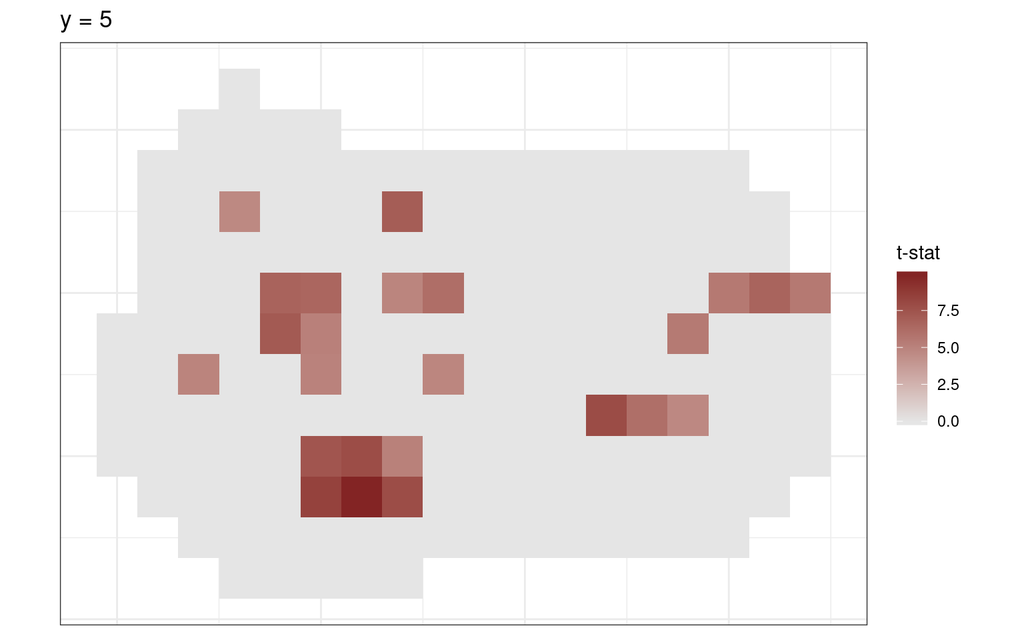

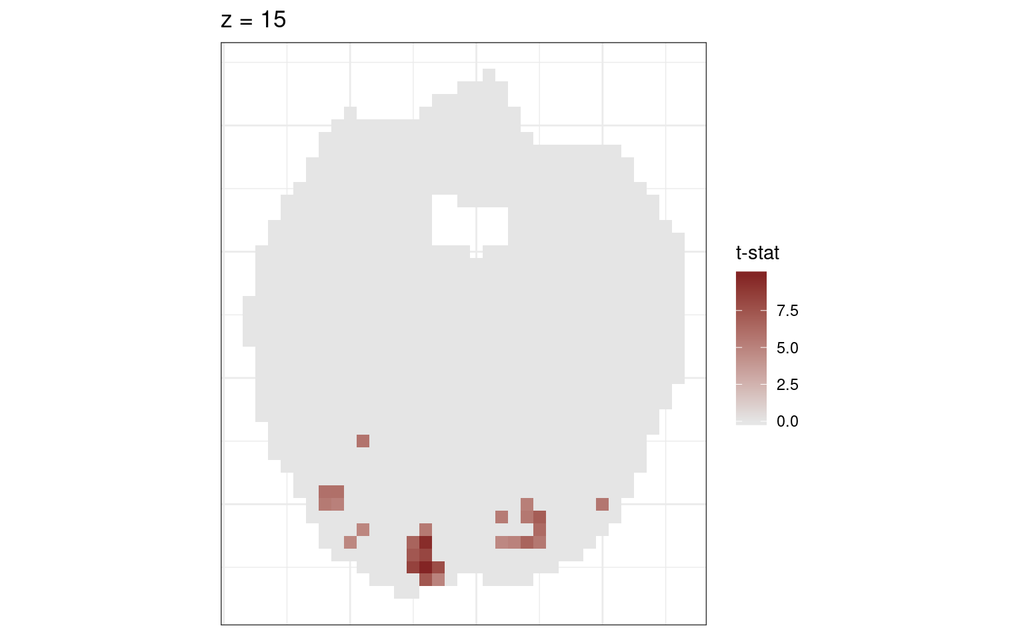

This time, we get only 195 activations. However, the Bonferroni correction tends to be overly conservative.

We can also try a Feedman-Lane permutation test:

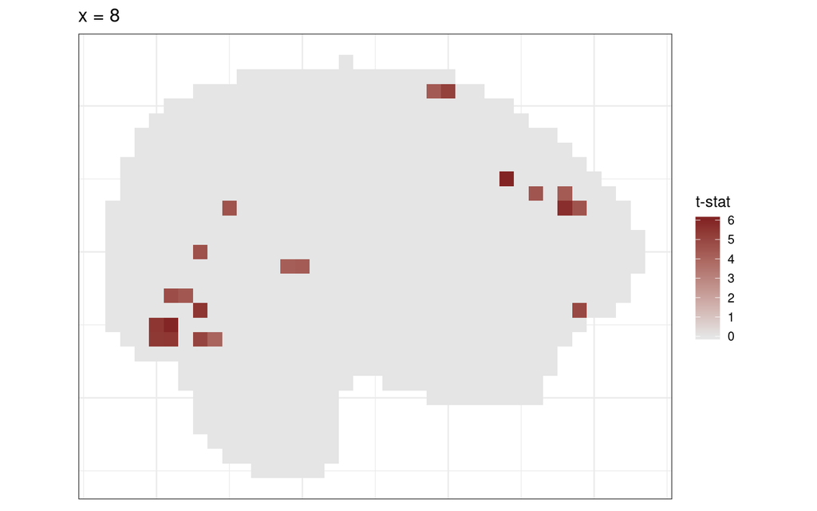

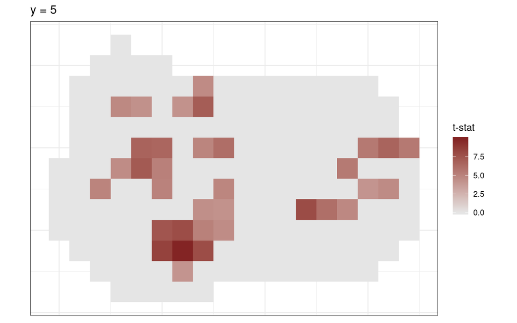

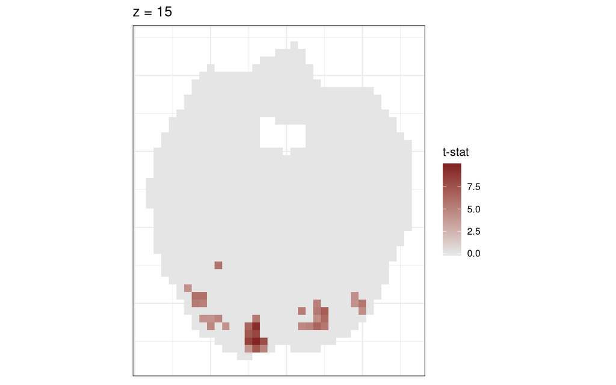

Using the same cutoff of $\alpha = 0.05$, we get $335$ voxels flagged as activated.